# Assignment 9

Allison Tessman

2024-03-07

# Question 1

Working with the inflation data, to do the follows:

- Create a time series of three-month inflation rate

```r
library(forecast)
# import the data
df = read.csv("https://bryantstats.github.io/math475/assignments/inflation.csv")

# define the series
yt = ts(df$pai3, frequency = 12, start = c(1950, 2))
```

- Plot the series and the ACF to check if the series is stationary

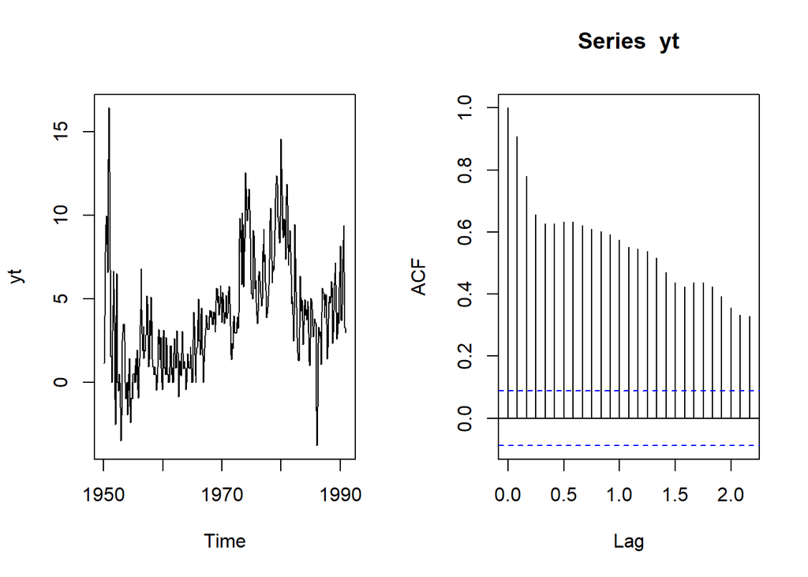

```r
# check for stationary
par(mfrow = c(1, 2))
plot(yt)
acf(yt)
```

- Create the differenced series and check for stationary

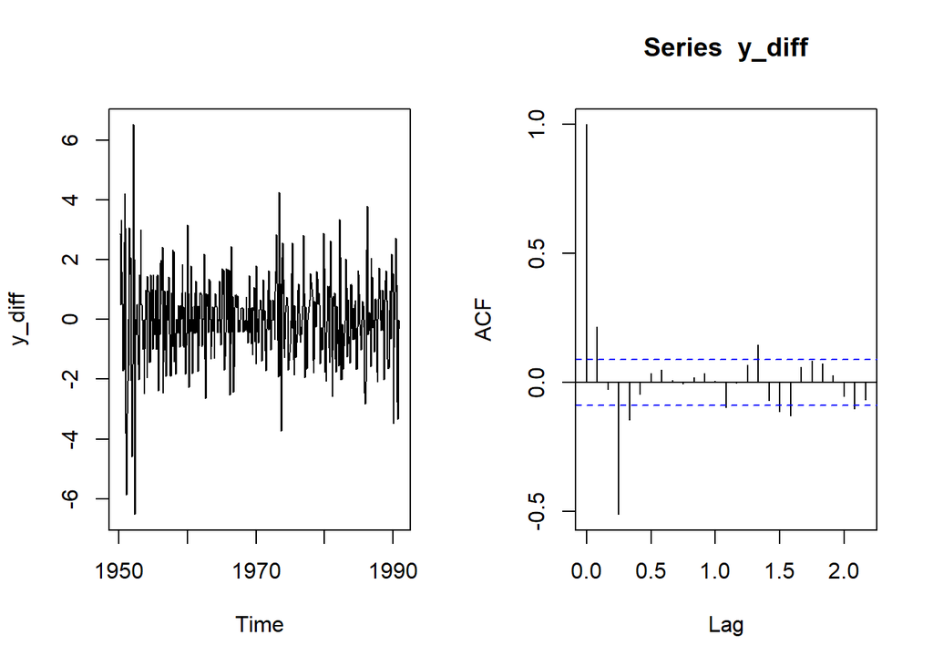

```r
# create the differenced series for stationary
y_diff = diff(yt)

# check for stationary
par(mfrow = c(1, 2))
plot(y_diff)
acf(y_diff)
```

- Fit the MA(1) model to the series and plot the fitted series

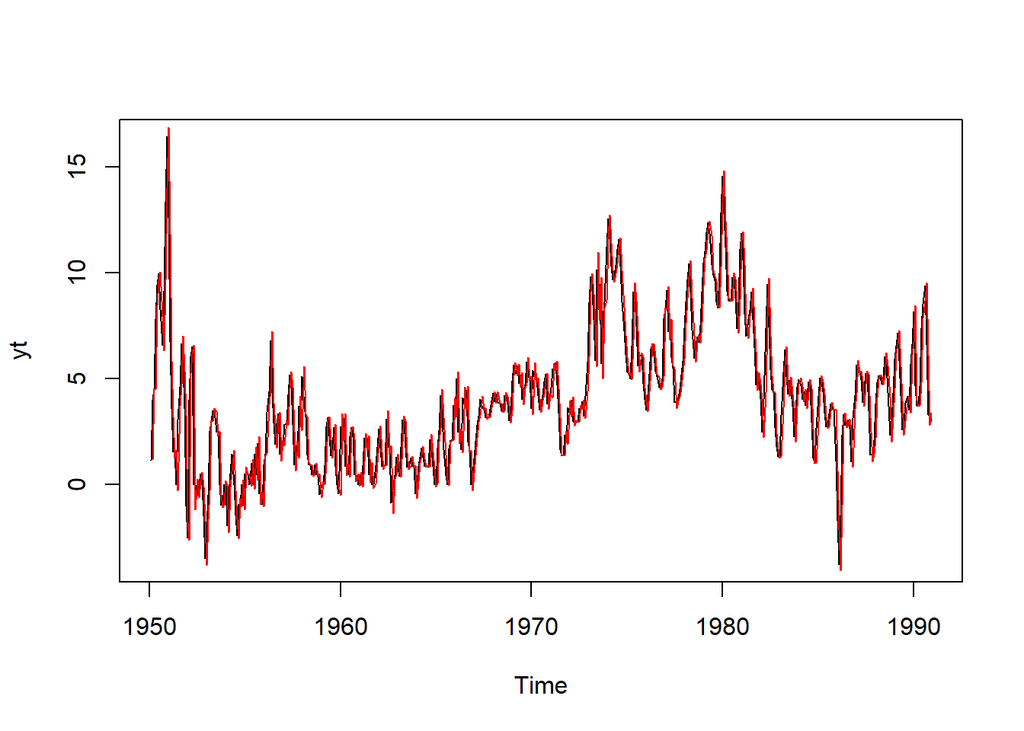

```r
# fit the MA(1) model to the differenced series
y_ma = arima(y_diff, order = c(0,0,1))

# plot the fitted series
plot(yt)
lines(yt-y_ma$residuals, col = "red")
```

- Make prediction on the next value of three-month inflation rate

```r
# make predictions
d_n = forecast(y_ma, h = 1)
y_next = d_n$mean + yt[length(yt)]
y_next = as.numeric(y_next)
y_next
```

```
## [1] 2.909541
```

- Fit the AR(1) model to the series and plot the fitted series

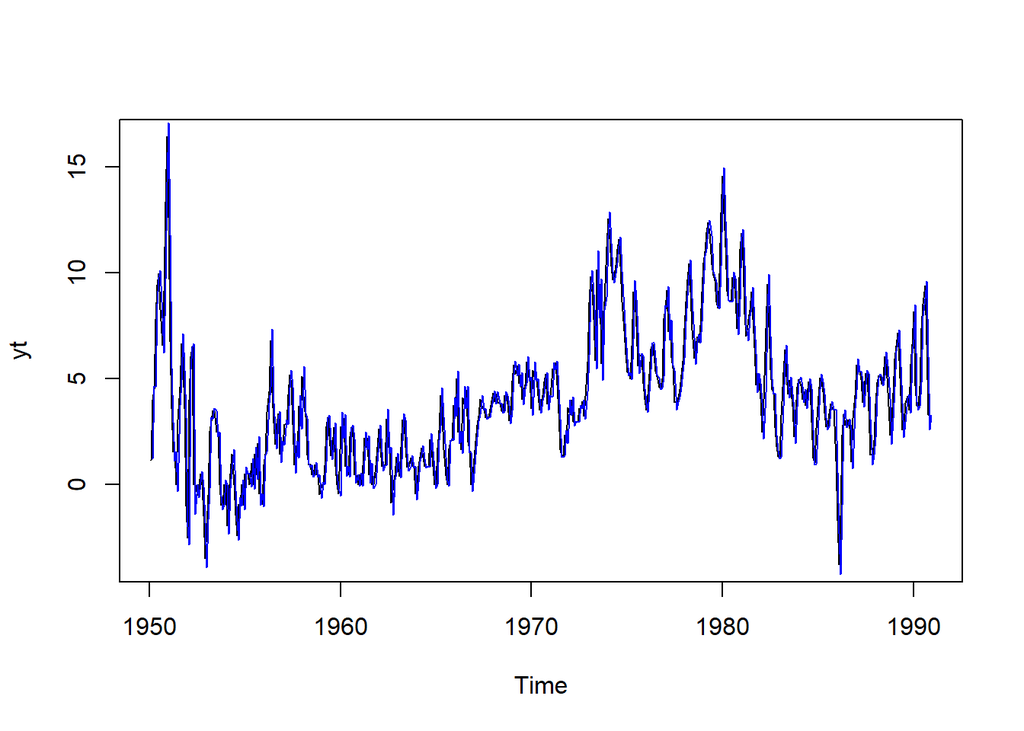

```r
y_ar = arima(y_diff, order = c(1,0,0))

plot(yt)
lines(yt-y_ar$residuals, col = "blue")
```

- Make prediction on the next value of three-month inflation rate

```r
# make predictions
d_n = forecast(y_ar, h = 1)
y_next = d_n$mean + yt[length(yt)]
y_next = as.numeric(y_next)
y_next
```

```
## [1] 2.916789
```

# Question 2

Consider the Consumption data. This is a quarterly data on consumption and expenditure in Canada. The series started from Quarter 1 in 1947.

The time series containing :

- yd: personal disposable income, 1986 dollars
- ce: personal consumption expenditure, 1986 dollars

Let Yt be the personal consumption expenditure series. Assume that the differenced series of Yt is stationary.

- Use the MA(1) model to fit the differenced series and make a prediction on the next value of Yt
- Plot the fitted Yt and the Yt on the same graph.

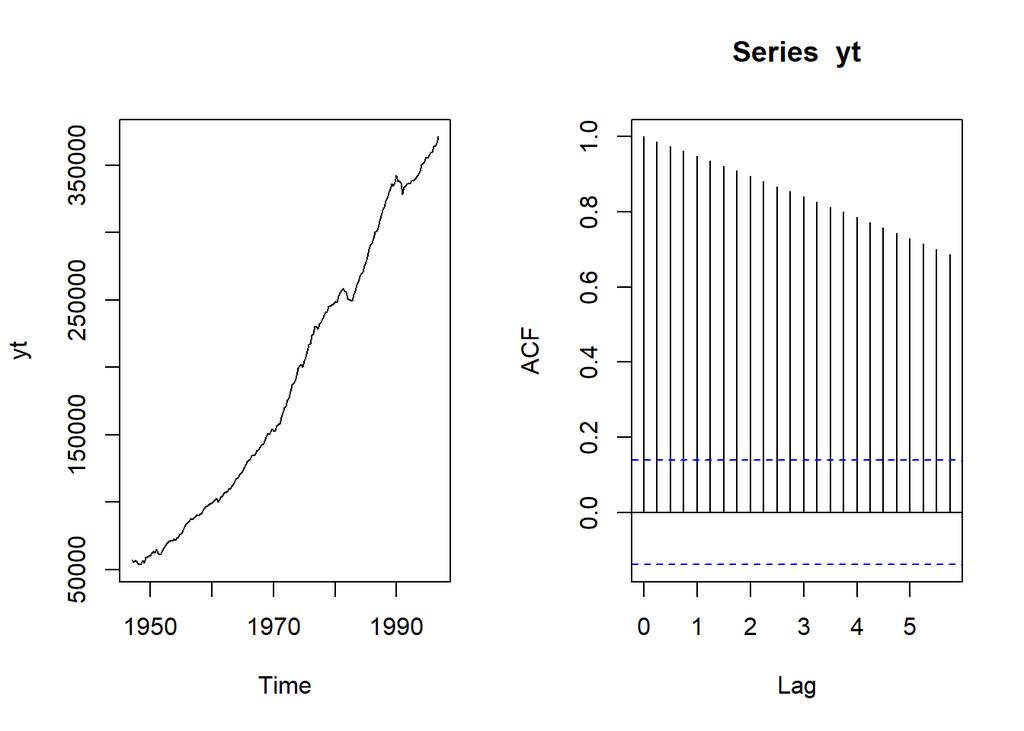

```r
# import the data
df = read.csv("https://bryantstats.github.io/math475/assignments/consumption.csv")

# define the series
yt = ts(df$ce, frequency = 4, start = c(1947, 1))

# check for stationary
par(mfrow = c(1, 2))
plot(yt)
acf(yt)
```

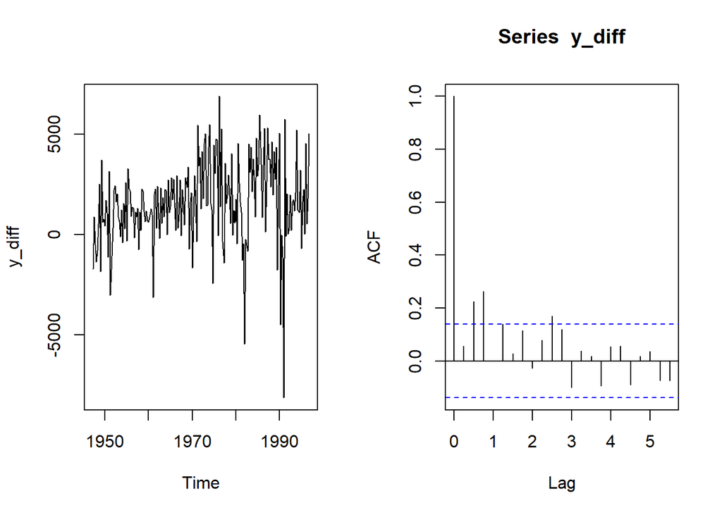

```r
# create the differenced series for stationary
y_diff = diff(yt)

# check for stationary
par(mfrow = c(1, 2))
plot(y_diff)
acf(y_diff)
```

```
## [1] 372954.2
```

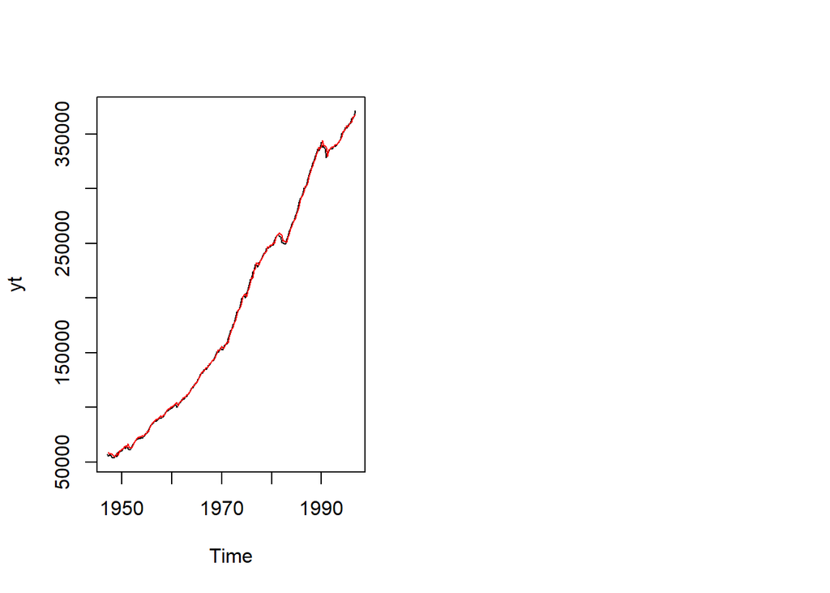

```r
# fit the MA(1) model to the differenced series
y_ma = arima(y_diff, order = c(0,0,1))

# plot the fitted series
plot(yt)
lines(yt-y_ma$residuals, col = "red")

# make predictions
d_n = forecast(y_ma, h = 1)
y_next = d_n$mean + yt[length(yt)]
y_next = as.numeric(y_next)
y_next
```